# Examples of time series modeling in python, with classical models and RNNs

**Predicting Chicago Transit Authority ridership using RNNs** (From Geron, Ch. 15)

```python
import numpy as np
import tensorflow as tf
import matplotlib.pyplot as plt
import pandas as pd
```

```python
pwd
```

```
'/Users/marciero/Library/CloudStorage/Dropbox/DS-stats/DSC_DSP_courses/DSC360/mod_06_RNN'
```

#### Read in the data.

The `parse_dates` argument converts to a pandas datetime object. Note that below we set "date" as the index. Thus "date" is no longer a column name.

```python
df = pd.read_csv("../../data/CTA_-_Ridership_-_Daily_Boarding_Totals_20240731.csv", parse_dates=["service_date"])

df.columns = ["date", "day_type", "bus", "rail", "total"]  # shorter names
df = df.sort_values("date").set_index("date")
df = df.drop("total", axis=1)  # no need for total, it's just bus + rail
df = df.drop_duplicates()  # remove duplicated months (2011-10 and 2014-07)
```

```python
df.head()
```

| date | day_type | bus | rail |
| --- | --- | --- | --- |
| 2001-01-01 | U | 297192 | 126455 |
| 2001-01-02 | W | 780827 | 501952 |
| 2001-01-03 | W | 824923 | 536432 |
| 2001-01-04 | W | 870021 | 550011 |
| 2001-01-05 | W | 890426 | 557917 |

The `day_type` is coded `W`: weekday, `A`: Saturday, `U`: Sunday/Holiday

Look at the first few months of 2024

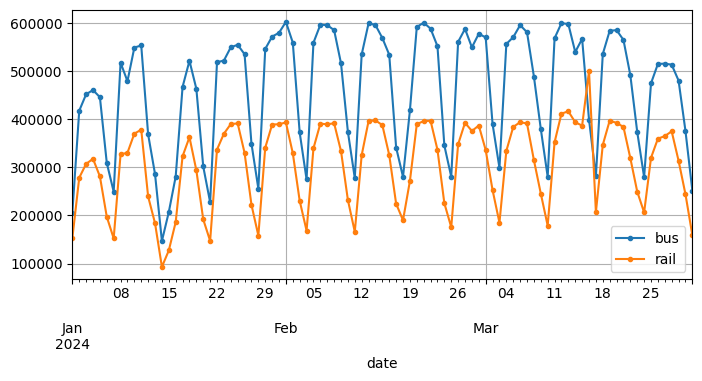

```python
import matplotlib.pyplot as plt

df["2024-01":"2024-03"].plot(grid=True, marker=".", figsize=(8, 3.5))
plt.show()
```

#### Differencing

Differencing is a technique used on seasonal and trended data. You can see there is the weekly periodicity- the diff removes the periodicity. Compare with for example, `diff(5)`. One can also decompose time series into seasonal (one or more) and trend components. See for example [Forecasting Principles and Practice](https://f0nzie.github.io/hyndman-bookdown-rsuite/) (fpp3) Chapter 3.

Below, the dotted plots on the top plot show the 7-day shifted values. You can see where the differenced values on the bottom plot are close to zero.

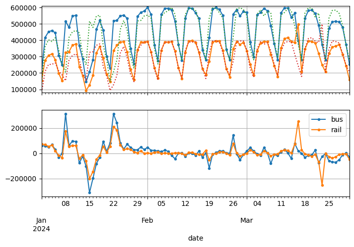

```python
diff_7 = df[["bus", "rail"]].diff(7)["2024-01":"2024-03"]

fig, axs = plt.subplots(2, 1, sharex=True, figsize=(8, 5))
df.plot(ax=axs[0], legend=False, marker=".")  # original time series
df.shift(7).plot(ax=axs[0], grid=True, legend=False, linestyle=":")  # lagged
diff_7.plot(ax=axs[1], grid=True, marker=".")  # 7-day difference time series
axs[0].set_ylim([80_000, 610_000])  # extra code – beautifies the plot
plt.show()
```

We can see a few places where the differences were large, for example near Jan 15. We might check that day

```python
df.loc["2024-01-13":"2024-01-17"]["day_type"]
```

```
date
2024-01-13    A
2024-01-14    U
2024-01-15    W
2024-01-16    W
2024-01-17    W
Name: day_type, dtype: object
```

It's coded as weekday, but it was in fact MLK day, a Monday, as you can check.

#### MAPE

Now lets compute the MAPE-mean absolute percent error

```python
targets =  df[["bus", "rail"]]["2024-01":"2024-03"]
preds = df.shift(7)[["bus", "rail"]]["2024-01":"2024-03"]

np.mean(np.abs((targets - preds) / targets), axis=0) * 100
```

```
bus     12.308121
rail    14.010759
dtype: float64
```

We can also see yearly seasonality, as well as some trending.

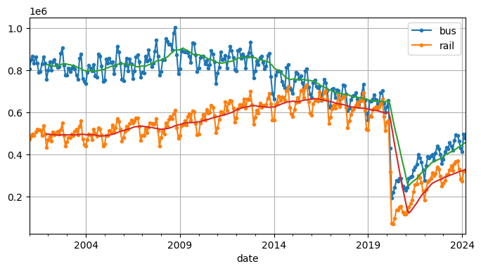

```python
period = slice("2001", "2024")
df_monthly = df[["bus", "rail"]].resample('ME').mean()  # compute the mean for each month
rolling_average_12_months = df_monthly[period].rolling(window=12).mean()

fig, ax = plt.subplots(figsize=(8, 4))
df_monthly[period].plot(ax=ax, marker=".")
rolling_average_12_months.plot(ax=ax, grid=True, legend=False)
plt.show()
```

We can do seasonal-yearly- differencing here, which removes the trending- asisd from pandemic craziness.

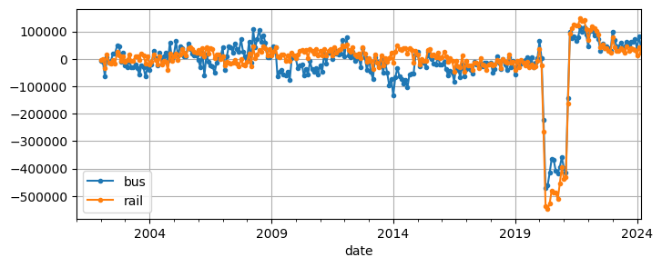

```python
df_monthly.diff(12)[period].plot(grid=True, marker=".", figsize=(8, 3))

plt.show()
```

#### ARIMA models

We use statsmodels library. You will need to install this. As we have seen, the ARIMA model is auto-regressive integrated moving average model. It and exponential smoothing are the two most widely used time series modeling approaches. See fpp3 Chapters 9 and 8; respectively.

The model below is an autoregressive (AR) model with seasonal components that is modeled as moving average (MA), and with seasonal differencing of 7. Seasonal ARIMA models are also reffered to as SARIMA. We just consider the rail data.

Notice we pass the data to the model at construction, rather than at fit, as in sklearn and keras. See Geron, and also the [statsmodels docs](https://www.statsmodels.org/stable/generated/statsmodels.tsa.arima.model.ARIMA.html)

```python
from statsmodels.tsa.arima.model import ARIMA

origin, today = "2023-01-01", "2023-05-31" ## pick a several weeks time period
rail_series = df.loc[origin:today]["rail"].asfreq("D") # "D" gives daily as freq
model = ARIMA(rail_series,
              order=(1, 0, 0), ## in fact this model is an AR only model.
              seasonal_order=(0, 1, 1, 7)) # seasonal model orders and differencing.

model = model.fit()
y_pred = model.forecast()
```

Compare predicted and target

```python
y_pred
```

```
2023-06-01    391646.97475
Freq: D, dtype: float64
```

```python
## Target value
df["rail"].loc["2023-06-01"]
```

```
393187
```

Raw difference

```python
df["rail"].loc["2023-06-01"] - y_pred.iloc[0]
```

```
1540.025249932718
```

Percent error.

```python
np.abs((y_pred.iloc[0] - df["rail"].loc["2023-06-01"]))/df["rail"].loc["2023-06-01"] *100
```

```
0.3916775605329571
```

```python
model.forecast()
model.forecast(steps=7)
```

```
2023-06-01    391646.974750
2023-06-02    353645.849161
2023-06-03    286384.837052
2023-06-04    242286.363761
2023-06-05    219999.201177
2023-06-06    384257.630021
2023-06-07    390318.989966
Freq: D, Name: predicted_mean, dtype: float64
```

We may have gotten lucky above with the day. Below we train a new model each day and find mean absolute error. This is just to see how well the one day arima forecast does on average.

```python
origin, start_date, end_date = "2023-01-01", "2023-03-01", "2023-05-31"
time_period = pd.date_range(start_date, end_date)
rail_series = df.loc[origin:end_date]["rail"].asfreq("D")
y_preds = []
for today in time_period.shift(-1):
    model = ARIMA(rail_series[origin:today],  # train on data up to "today"
                  order=(1, 0, 0),
                  seasonal_order=(0, 1, 1, 7))
    model = model.fit()  # note that we retrain the model every day!
    y_pred = model.forecast().iloc[0]
    y_preds.append(y_pred)

y_preds = pd.Series(y_preds, index=time_period)
mae = (y_preds - rail_series[time_period]).abs().mean()
mae
```

```
19135.61164006469
```

So we did get lucky. Still not terribly bad. We can compare true and model predictions

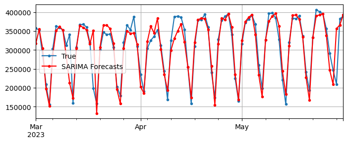

```python
#displays the SARIMA forecasts
fig, ax = plt.subplots(figsize=(8, 3))
rail_series.loc[time_period].plot(label="True", ax=ax, marker=".", grid=True)
ax.plot(y_preds, color="r", marker=".", label="SARIMA Forecasts")
plt.legend()
plt.show()
```

We can revise the code to give predictions seven days ahead, and plot.

```python
y_preds = []
for today in time_period.shift(-1):
    model = ARIMA(rail_series[origin:today],  # train on data up to "today"
                  order=(1, 0, 0),
                  seasonal_order=(0, 1, 1, 7))
    model = model.fit()  # note that we retrain the model every day!
    y_pred = model.forecast(steps = 7).iloc[6]
    y_preds.append(y_pred)

y_preds = pd.Series(y_preds, index=time_period)
```

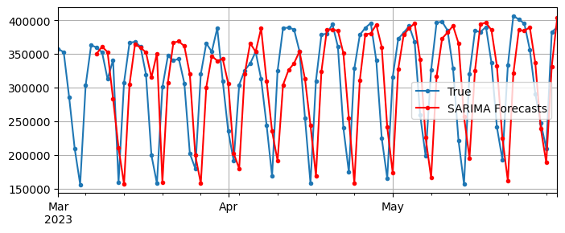

```python
# Shift the predictions by 7 days to align with the actual values
y_preds_shifted = y_preds.shift(7)

# Plot the actual values and the shifted predictions
fig, ax = plt.subplots(figsize=(8, 3))
rail_series.loc[time_period].plot(label="True", ax=ax, marker=".", grid=True)
ax.plot(y_preds_shifted, color="r", marker=".", label="SARIMA Forecasts")
plt.legend()
plt.show()
```

## Autocorrelation.

Describes the correlations between lagged values; that is, time series with itself, at different lagged values. An assumption is that the correlations only depend on the lag, and not where along the time series you are. Such time series are said to be *stationary*. See fpp3 Section 2.8 (though stationarity is not mentioned until Ch. 7).

Below you can clearly see the weekly seasonality evidenced by large correlations at multiples of 7.

Stationarity is a desireable property for statistical modeling that is usually violated.

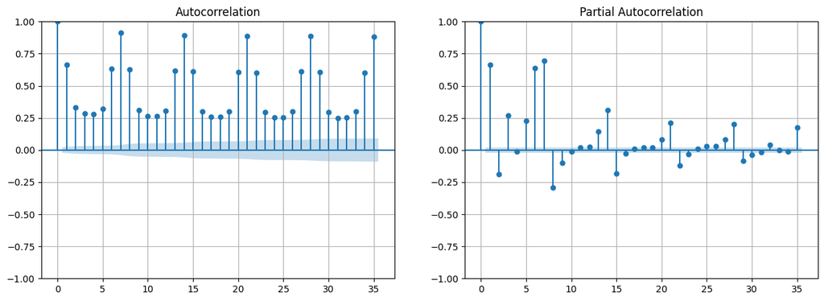

```python
# extra code – shows how to plot the Autocorrelation Function (ACF) and the
#              Partial Autocorrelation Function (PACF)

from statsmodels.graphics.tsaplots import plot_acf, plot_pacf

fig, axs = plt.subplots(nrows=1, ncols=2, figsize=(15, 5))
plot_acf(df[period]["rail"], ax=axs[0], lags=35)
axs[0].grid()
plot_pacf(df[period]["rail"], ax=axs[1], lags=35, method="ywm")
axs[1].grid()
plt.show()
```

## A Simple RNN model

First consider just the time series without any features. Later we will use day_type as a predictor.

Split the time series into three periods, for training, validation and testing.

Below is analogous to what Chollet is doing in Ch. 10 code, except note here that there are no predictors- these data sets only contain `rail`. We are using the sequence to forecast itself. In Chollet, there are predictors in addition to the target. Later we incorporate predictors.

```python
import tensorflow as tf

rail_train = df["rail"]["2021-01":"2023-6"] / 1e6
rail_valid = df["rail"]["2023-7":"2023-12"] / 1e6
rail_test = df["rail"]["2024-01":] / 1e6
```

```python
seq_length = 56
tf.random.set_seed(42)  # extra code – ensures reproducibility
train_ds = tf.keras.utils.timeseries_dataset_from_array(
    rail_train.to_numpy(),
    targets=rail_train[seq_length:],
    sequence_length=seq_length,
    batch_size=32,
    shuffle=True,
    seed=42
)
valid_ds = tf.keras.utils.timeseries_dataset_from_array(
    rail_valid.to_numpy(),
    targets=rail_valid[seq_length:],
    sequence_length=seq_length,
    batch_size=32
)
```

We define a convenience function.

```python
def fit_and_evaluate(model, train_set, valid_set, learning_rate, epochs=5):
    early_stopping_cb = tf.keras.callbacks.EarlyStopping(
        monitor="val_mae", patience=50, restore_best_weights=True)
    opt = tf.keras.optimizers.SGD(learning_rate=learning_rate, momentum=0.9)
    model.compile(loss=tf.keras.losses.Huber(), optimizer=opt, metrics=["mae"])
    history = model.fit(train_set, validation_data=valid_set, epochs=epochs,
                        callbacks=[early_stopping_cb])
    valid_loss, valid_mae = model.evaluate(valid_set)
    return valid_mae * 1e6
```

```python
from tensorflow.keras.layers import Input, SimpleRNN, Dense
from tensorflow.keras.models import Model


inputs = Input(shape=[None, 1])
x = SimpleRNN(32,  return_sequences=True, activation = "tanh")(inputs)
x = SimpleRNN(32,  return_sequences=True, activation="tanh")(x)
x = SimpleRNN(32, activation="tanh")(x)
outputs = Dense(1)(x)

model = Model(inputs, outputs)
```

```python
fit_and_evaluate(model, train_ds, valid_ds, learning_rate=0.02)
```

```
27/27 ━━━━━━━━━━━━━━━━━━━━ 5s 73ms/step - loss: 0.1462 - mae: 0.4244 - val_loss: 0.0119 - val_mae: 0.1344
27/27 ━━━━━━━━━━━━━━━━━━━━ 1s 19ms/step - loss: 0.0053 - mae: 0.0842 - val_loss: 0.0118 - val_mae: 0.1333
27/27 ━━━━━━━━━━━━━━━━━━━━ 1s 19ms/step - loss: 0.0040 - mae: 0.0756 - val_loss: 0.0069 - val_mae: 0.1035
27/27 ━━━━━━━━━━━━━━━━━━━━ 1s 19ms/step - loss: 0.0032 - mae: 0.0686 - val_loss: 0.0090 - val_mae: 0.1174
27/27 ━━━━━━━━━━━━━━━━━━━━ 1s 19ms/step - loss: 0.0034 - mae: 0.0705 - val_loss: 0.0076 - val_mae: 0.1084
4/4 ━━━━━━━━━━━━━━━━━━━━ 0s 8ms/step - loss: 0.0077 - mae: 0.1100
```

```
103546.44060134888
```

## Multivariate time series

Here we use `day_type` and `bus` to predict `rail`

```python
df_mulvar = df[["bus", "rail"]] / 1e6  # use both bus & rail series as input
df_mulvar["next_day_type"] = df["day_type"].shift(-1)  # we know tomorrow's type
df_mulvar = pd.get_dummies(df_mulvar, dtype = int)  # one-hot. You need the dtype = int!
```

```python
from sklearn.preprocessing import OneHotEncoder
ohc = OneHotEncoder()
day_enc = ohc.fit_transform(df[["day_type"]])
day_df = pd.DataFrame(day_enc.toarray(), columns = ohc.get_feature_names_out())

df_mulvar = pd.concat([df[["bus", "rail"]], day_df], axis = 1)
```

```python
df_mulvar.head()
```

[output not shown]

```python
mulvar_train = df_mulvar["2021-01":"2023-6"]
mulvar_valid = df_mulvar["2023-07":"2023-12"]
mulvar_test = df_mulvar["2024-01":]
```

In the following, `rail` is the target, and so `day_type` and `bus` are both predictors.

```python
tf.random.set_seed(42)  # extra code – ensures reproducibility

train_mulvar_ds = tf.keras.utils.timeseries_dataset_from_array(
    mulvar_train.to_numpy(),  # use all 5 columns as input
    targets=mulvar_train["rail"][seq_length:],  # forecast only the rail series
    sequence_length=seq_length,
    batch_size=32,
    shuffle=True,
    seed=42
)
valid_mulvar_ds = tf.keras.utils.timeseries_dataset_from_array(
    mulvar_valid.to_numpy(),
    targets=mulvar_valid["rail"][seq_length:],
    sequence_length=seq_length,
    batch_size=32
)
```

```python
tf.random.set_seed(42)  # extra code – ensures reproducibility
mulvar_model = tf.keras.Sequential([
    tf.keras.layers.SimpleRNN(32, input_shape=[None, 5]),
    tf.keras.layers.Dense(1)
])
```

```python
# extra code – compiles, fits, and evaluates the model, like earlier
fit_and_evaluate(mulvar_model, train_mulvar_ds, valid_mulvar_ds,
                 learning_rate=0.05)
```

```
27/27 ━━━━━━━━━━━━━━━━━━━━ 3s 42ms/step - loss: 0.0582 - mae: 0.2719 - val_loss: 0.0054 - val_mae: 0.0848
27/27 ━━━━━━━━━━━━━━━━━━━━ 0s 10ms/step - loss: 0.0049 - mae: 0.0792 - val_loss: 0.0025 - val_mae: 0.0584
27/27 ━━━━━━━━━━━━━━━━━━━━ 0s 9ms/step - loss: 0.0025 - mae: 0.0550 - val_loss: 0.0037 - val_mae: 0.0744
27/27 ━━━━━━━━━━━━━━━━━━━━ 0s 10ms/step - loss: 0.0015 - mae: 0.0446 - val_loss: 0.0015 - val_mae: 0.0452
27/27 ━━━━━━━━━━━━━━━━━━━━ 0s 9ms/step - loss: 0.0013 - mae: 0.0402 - val_loss: 0.0014 - val_mae: 0.0442
4/4 ━━━━━━━━━━━━━━━━━━━━ 0s 5ms/step - loss: 0.0014 - mae: 0.0454
```

```
44234.082102775574
```

# Below is optional.

## Multiple targets

We can even predict both rail and bus

```python
# extra code – build and train a multitask RNN that forecasts both bus and rail

tf.random.set_seed(42)

seq_length = 56
train_multask_ds = tf.keras.utils.timeseries_dataset_from_array(
    mulvar_train.to_numpy(),
    targets=mulvar_train[["bus", "rail"]][seq_length:],  # 2 targets per day
    sequence_length=seq_length,
    batch_size=32,
    shuffle=True,
    seed=42
)
valid_multask_ds = tf.keras.utils.timeseries_dataset_from_array(
    mulvar_valid.to_numpy(),
    targets=mulvar_valid[["bus", "rail"]][seq_length:],
    sequence_length=seq_length,
    batch_size=32
)

tf.random.set_seed(42)
multask_model = tf.keras.Sequential([
    tf.keras.layers.SimpleRNN(32, input_shape=[None, 5]),
    tf.keras.layers.Dense(2)
])

fit_and_evaluate(multask_model, train_multask_ds, valid_multask_ds,
                 learning_rate=0.02)
```

[output not shown]

```python
# extra code – evaluates the naive forecasts for bus
bus_naive = mulvar_valid["bus"].shift(7)[seq_length:]
bus_target = mulvar_valid["bus"][seq_length:]
(bus_target - bus_naive).abs().mean() * 1e6
```

```
43441.63157894738
```

```python
# extra code – evaluates the multitask RNN's forecasts both bus and rail
Y_preds_valid = multask_model.predict(valid_multask_ds)
for idx, name in enumerate(["bus", "rail"]):
    mae = 1e6 * tf.keras.metrics.mean_absolute_error(
        mulvar_valid[name][seq_length:], Y_preds_valid[:, idx])
    print(name, int(mae))
```

```
bus 26369
rail 25330
```

## Forecasting Several Steps Ahead

```python
rail_valid.to_numpy()[np.newaxis, :seq_length, np.newaxis].shape
```

```
(1, 56, 1)
```

```python
import numpy as np

X = rail_valid.to_numpy()[np.newaxis, :seq_length, np.newaxis]
for step_ahead in range(14):
    y_pred_one = univar_model.predict(X)
    X = np.concatenate([X, y_pred_one.reshape(1, 1, 1)], axis=1)
```

[figure not shown]

```python
# extra code – generates and saves Figure 15–11

# The forecasts start on 2019-02-26, as it is the 57th day of 2019, and they end
# on 2019-03-11. That's 14 days in total.
Y_pred = pd.Series(X[0, -14:, 0],
                   index=pd.date_range("2019-02-26", "2019-03-11"))

fig, ax = plt.subplots(figsize=(8, 3.5))
(rail_valid * 1e6)["2019-02-01":"2019-03-11"].plot(
    label="True", marker=".", ax=ax)
(Y_pred * 1e6).plot(
    label="Predictions", grid=True, marker="x", color="r", ax=ax)
ax.vlines("2019-02-25", 0, 1e6, color="k", linestyle="--", label="Today")
ax.set_ylim([200_000, 800_000])
plt.legend(loc="center left")
save_fig("forecast_ahead_plot")
plt.show()
```

Now let's create an RNN that predicts all 14 next values at once:

```python
tf.random.set_seed(42)  # extra code – ensures reproducibility

def split_inputs_and_targets(mulvar_series, ahead=14, target_col=1):
    return mulvar_series[:, :-ahead], mulvar_series[:, -ahead:, target_col]

ahead_train_ds = tf.keras.utils.timeseries_dataset_from_array(
    mulvar_train.to_numpy(),
    targets=None,
    sequence_length=seq_length + 14,
    batch_size=32,
    shuffle=True,
    seed=42
).map(split_inputs_and_targets)
ahead_valid_ds = tf.keras.utils.timeseries_dataset_from_array(
    mulvar_valid.to_numpy(),
    targets=None,
    sequence_length=seq_length + 14,
    batch_size=32
).map(split_inputs_and_targets)
```

```python
tf.random.set_seed(42)

ahead_model = tf.keras.Sequential([
    tf.keras.layers.SimpleRNN(32, input_shape=[None, 5]),
    tf.keras.layers.Dense(14)
])
```

```python
# extra code – compiles, fits, and evaluates the model, like earlier
fit_and_evaluate(ahead_model, ahead_train_ds, ahead_valid_ds,
                 learning_rate=0.02)
```

```
<<303 more lines>>
```

```
35017.29667186737
```

```python
X = mulvar_valid.to_numpy()[np.newaxis, :seq_length]  # shape [1, 56, 5]
Y_pred = ahead_model.predict(X)  # shape [1, 14]
```

Now let's create an RNN that predicts the next 14 steps at each time step. That is, instead of just forecasting time steps 56 to 69 based on time steps 0 to 55, it will forecast time steps 1 to 14 at time step 0, then time steps 2 to 15 at time step 1, and so on, and finally it will forecast time steps 56 to 69 at the last time step. Notice that the model is causal: when it makes predictions at any time step, it can only see past time steps.

To prepare the datasets, we can use `to_windows()` twice, to get sequences of consecutive windows, like this:

```python
my_series = tf.data.Dataset.range(7)
dataset = to_windows(to_windows(my_series, 3), 4)
list(dataset)
```

```
[<tf.Tensor: shape=(4, 3), dtype=int64, numpy=
 array([[0, 1, 2],
        [1, 2, 3],
        [2, 3, 4],
        [3, 4, 5]])>,
 <tf.Tensor: shape=(4, 3), dtype=int64, numpy=
 array([[1, 2, 3],
        [2, 3, 4],
        [3, 4, 5],
        [4, 5, 6]])>]
```

Then we can split these elements into the desired inputs and targets:

```python
dataset = dataset.map(lambda S: (S[:, 0], S[:, 1:]))
list(dataset)
```

```
[(<tf.Tensor: shape=(4,), dtype=int64, numpy=array([0, 1, 2, 3])>,
  <tf.Tensor: shape=(4, 2), dtype=int64, numpy=
  array([[1, 2],
         [2, 3],
         [3, 4],
         [4, 5]])>),
 (<tf.Tensor: shape=(4,), dtype=int64, numpy=array([1, 2, 3, 4])>,
  <tf.Tensor: shape=(4, 2), dtype=int64, numpy=
  array([[2, 3],
         [3, 4],
         [4, 5],
         [5, 6]])>)]
```

Let's wrap this idea into a utility function. It will also take care of shuffling (optional) and batching:

```python
def to_seq2seq_dataset(series, seq_length=56, ahead=14, target_col=1,
                       batch_size=32, shuffle=False, seed=None):
    ds = to_windows(tf.data.Dataset.from_tensor_slices(series), ahead + 1)
    ds = to_windows(ds, seq_length).map(lambda S: (S[:, 0], S[:, 1:, 1]))
    if shuffle:
        ds = ds.shuffle(8 * batch_size, seed=seed)
    return ds.batch(batch_size)
```

```python
seq2seq_train = to_seq2seq_dataset(mulvar_train, shuffle=True, seed=42)
seq2seq_valid = to_seq2seq_dataset(mulvar_valid)
```

```python
tf.random.set_seed(42)  # extra code – ensures reproducibility
seq2seq_model = tf.keras.Sequential([
    tf.keras.layers.SimpleRNN(32, return_sequences=True, input_shape=[None, 5]),
    tf.keras.layers.Dense(14)
    # equivalent: tf.keras.layers.TimeDistributed(tf.keras.layers.Dense(14))
    # also equivalent: tf.keras.layers.Conv1D(14, kernel_size=1)
])
```

```python
fit_and_evaluate(seq2seq_model, seq2seq_train, seq2seq_valid,
                 learning_rate=0.1)
```

```
<<219 more lines>>
```

```
45928.88057231903
```

```python
X = mulvar_valid.to_numpy()[np.newaxis, :seq_length]
y_pred_14 = seq2seq_model.predict(X)[0, -1]  # only the last time step's output
```

```python
Y_pred_valid = seq2seq_model.predict(seq2seq_valid)
for ahead in range(14):
    preds = pd.Series(Y_pred_valid[:-1, -1, ahead],
                      index=mulvar_valid.index[56 + ahead : -14 + ahead])
    mae = (preds - mulvar_valid["rail"]).abs().mean() * 1e6
    print(f"MAE for +{ahead + 1}: {mae:,.0f}")
```

```
MAE for +1: 25,519
MAE for +2: 26,274
MAE for +3: 27,054
MAE for +4: 29,324
MAE for +5: 28,992
MAE for +6: 31,739
MAE for +7: 32,847
MAE for +8: 33,282
MAE for +9: 33,072
MAE for +10: 29,752
MAE for +11: 37,468
MAE for +12: 35,125
MAE for +13: 34,614
MAE for +14: 34,322
```